# Downloading the QuakeScope pick catalogue for a region and a period

The first notebook reads one network-month. This one does what a study needs: **choose stations by place and time, mirror every partition that covers them, query the mirror, check which station-days were actually processed, and export for an associator.** Anonymous throughout; nothing here needs an AWS account.

Worked example: the Monte Cristo Range, Nevada, M6.5 of 2020-05-15, with a 1.5 degree box and the two months from May 1 to June 30. Change the four values in section 2 and everything below follows.

| bucket | `s3://quakescope-picks-2026`, us-east-2, public-read |
| --- | --- |
| catalogue | `western`: 1986 to 2026, PhaseNet `original`, P and S thresholds 0.2 (three campaign eras, the fill stations, repair passes and the 2026-10 re-read, all under one prefix) |
| layout | `<campaign>/picks/network=<NET>/year=<YYYY>/month=<MM>/<shard_id>.parquet`, plus `manifests/`, `runs/`, `stations.parquet` |
| reference | [`docs/data_access.md`](https://github.com/SeisSCOPED/QuakeScope/blob/main/docs/data_access.md) |

## 1. Setup

```python
import datetime, json, time
from concurrent.futures import ThreadPoolExecutor
from pathlib import Path

import duckdb
import numpy as np
import pandas as pd
import matplotlib.pyplot as plt
import s3fs

BUCKET = "quakescope-picks-2026"
fs = s3fs.S3FileSystem(anon=True)
MIRROR = Path("quakescope_mirror")          # local tree, same layout as the bucket
MIRROR.mkdir(exist_ok=True)

CATALOGUE = "western"                       # one prefix, years 1986 to 2026

C_P, C_S = "#2a78d6", "#eb6834"
plt.rcParams.update({"figure.dpi": 110, "axes.spines.top": False, "axes.spines.right": False})
```

## 2. Choose a region and a period

Four values. The box is in degrees; the period is inclusive of both dates.

```python
CENTER_LAT, CENTER_LON, HALF_DEG = 38.169, -117.850, 1.5          # Monte Cristo Range M6.5, 2020-05-15
START, END = datetime.date(2020, 5, 1), datetime.date(2020, 6, 30)

LAT0, LAT1 = CENTER_LAT - HALF_DEG, CENTER_LAT + HALF_DEG
LON0, LON1 = CENTER_LON - HALF_DEG, CENTER_LON + HALF_DEG
print(f"box {LAT0:.2f} to {LAT1:.2f} N, {LON0:.2f} to {LON1:.2f} E, {START} to {END}")
```

```
box 36.67 to 39.67 N, -119.35 to -116.35 E, 2020-05-01 to 2020-06-30
```

### Stations in the box, operating in the period

`stations.parquet` is the table the catalogue was planned from. `start_date` and `end_date` are Parquet dates, so they compare directly with a `datetime.date`; a station still operating carries `3000-01-01` rather than a null, so a filter like `end_date >= START` keeps it instead of dropping it.

Until 2026-09-29 these two columns were a `YYYY.DDD` float, which is kept beside them as `start_yearday` and `end_yearday`. Do not decode that float by formatting it as a string: `str(2010.21)` is `"2010.21"` and reads as day 21, where the value means day 210.

```python
stations = pd.read_parquet(f"s3://{BUCKET}/{CATALOGUE}/stations.parquet", storage_options={"anon": True})
in_box = stations[stations.latitude.between(LAT0, LAT1) & stations.longitude.between(LON0, LON1)]
# Dates compare with dates. No decoding, which is the point of the change.
sel = in_box[(in_box.start_date <= END) & (in_box.end_date >= START)].copy()
# Network from `id`, not `network_code`: tables written before the 2026-10 fix
# carry CSV-parse damage in the code columns; `id` never did.
sel["net"] = sel["id"].str.split(".").str[0]
NETWORKS = sorted(sel.net.unique())
print(f"{len(in_box):,} station-locations in the box, {len(sel):,} operating in the period, "
      f"{len(NETWORKS)} networks: {NETWORKS}")
print(sel.net.value_counts().to_string())
```

```
553 station-locations in the box, 166 operating in the period, 10 networks: ['BK', 'CI', 'GS', 'IM', 'LB', 'NC', 'NN', 'NP', 'SN', 'ZG']
net
NN    49
NC    44
NP    34
IM    13
SN     7
BK     6
CI     6
LB     3
GS     2
ZG     2
```

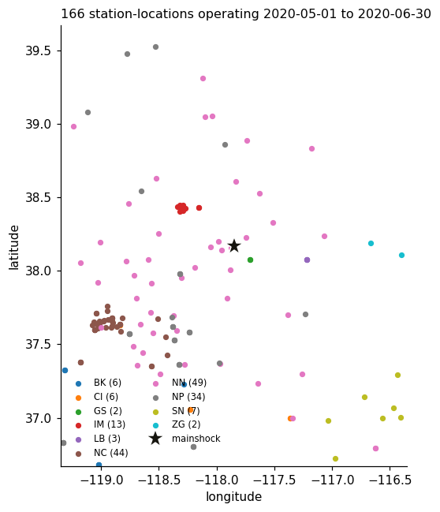

```python
fig, ax = plt.subplots(figsize=(6.5, 6))
for net, g in sel.groupby("net"):
    ax.scatter(g.longitude, g.latitude, s=14, label=f"{net} ({len(g)})")
ax.plot(CENTER_LON, CENTER_LAT, marker="*", ms=16, color="#16150f", mec="w", ls="none", label="mainshock")
ax.set_xlim(LON0, LON1); ax.set_ylim(LAT0, LAT1); ax.set_aspect(1 / np.cos(np.radians(CENTER_LAT)))
ax.set_xlabel("longitude"); ax.set_ylabel("latitude")
ax.legend(fontsize=7.5, ncol=2, frameon=False, loc="lower left")
ax.set_title(f"{len(sel)} station-locations operating {START} to {END}", loc="left", fontsize=10.5)
fig.tight_layout()
```

## 3. Which partitions cover them

A partition is `(campaign, network, year, month)`. The era decides the campaign; a network partition holds every station of that network, so the station filter is applied to the rows after the download (section 5).

```python
def partitions(networks, start, end):
    out = []
    d = start.replace(day=1)
    while d <= end:
        for net in networks:
            out.append((CATALOGUE, net, d.year, d.month))
        d = (d.replace(day=28) + datetime.timedelta(days=4)).replace(day=1)
    return out

PARTS = partitions(NETWORKS, START, END)
print(f"{len(PARTS)} partitions, e.g. {PARTS[:3]}")
```

```
20 partitions, e.g. [('western', 'BK', 2020, 5), ('western', 'CI', 2020, 5), ('western', 'GS', 2020, 5)]
```

## 4. Mirror them

```python
def sync(camp, net, year, month):
    # Mirror one partition; return (files fetched, bytes fetched, files already present).
    prefix = f"{camp}/picks/network={net}/year={year}/month={month:02d}/"
    local = MIRROR / prefix
    local.mkdir(parents=True, exist_ok=True)
    try:
        remote = fs.ls(f"{BUCKET}/{prefix}", detail=True)      # one LIST
    except FileNotFoundError:                                  # no picks were written for this partition
        remote = []
    have = {p.name for p in local.glob("*.parquet")}
    todo = [o for o in remote if Path(o["name"]).name not in have]
    if todo:
        fs.get([o["name"] for o in todo], [str(local / Path(o["name"]).name) for o in todo])
    return len(todo), sum(o["size"] for o in todo), len(have)

t0 = time.time(); n_new = b_new = n_have = 0
for camp, net, year, month in PARTS:
    n, b, h = sync(camp, net, year, month)
    n_new += n; b_new += b; n_have += h
print(f"fetched {n_new:,} files, {b_new / 1e6:,.0f} MB in {time.time() - t0:.0f} s; {n_have:,} already mirrored")
empty = [p for p in PARTS if not any((MIRROR / f"{p[0]}/picks/network={p[1]}/year={p[2]}/month={p[3]:02d}").glob("*.parquet"))]
print(f"{len(empty)} of {len(PARTS)} partitions hold no picks at all: {sorted({p[1] for p in empty})}")

print("\nequivalent shell commands:")
for camp, net, year, month in PARTS[:3]:
    p = f"{camp}/picks/network={net}/year={year}/month={month:02d}/"
    print(f"aws s3 sync --no-sign-request s3://{BUCKET}/{p} {MIRROR}/{p}")
print(f"... ({len(PARTS)} partitions)")
```

```
fetched 1,606 files, 299 MB in 44 s; 0 already mirrored
2 of 20 partitions hold no picks at all: ['ZG']

equivalent shell commands:
aws s3 sync --no-sign-request s3://quakescope-picks-2026/western/picks/network=BK/year=2020/month=05/ quakescope_mirror/western/picks/network=BK/year=2020/month=05/
aws s3 sync --no-sign-request s3://quakescope-picks-2026/western/picks/network=CI/year=2020/month=05/ quakescope_mirror/western/picks/network=CI/year=2020/month=05/
aws s3 sync --no-sign-request s3://quakescope-picks-2026/western/picks/network=GS/year=2020/month=05/ quakescope_mirror/western/picks/network=GS/year=2020/month=05/
... (20 partitions)
```

## 5. Query the mirror

DuckDB over the local tree, with the partition keys read from the paths. The station filter is a join against the selection table, so nothing outside the box is counted. Everything comes back aggregated; the raw rows are only pulled where they are needed.

```python
con = duckdb.connect()
con.register("sel", sel[["id", "network_code", "station_code", "latitude", "longitude", "elevation"]])
con.sql(f'''
    CREATE OR REPLACE VIEW picks AS
    SELECT p.*, s.latitude, s.longitude
    FROM read_parquet('{MIRROR}/{CATALOGUE}/picks/**/*.parquet', hive_partitioning=1) p
    JOIN sel s ON p.tid = s.id
    WHERE p.peak >= TIMESTAMP '{START}' AND p.peak < TIMESTAMP '{END + datetime.timedelta(days=1)}'
''')

t0 = time.time()
totals = con.sql("SELECT pha, count(*) AS picks, count(DISTINCT tid) AS stations, round(avg(conf), 3) AS mean_conf "
                 "FROM picks GROUP BY pha ORDER BY pha").df()
print(f"{time.time() - t0:.1f} s")
totals
```

```
0.2 s
```

|  | pha | picks | stations | mean_conf |
| --- | --- | --- | --- | --- |
| 0 | P | 2184746 | 95 | 0.636 |
| 1 | S | 2111152 | 90 | 0.566 |

```python
per_station = con.sql('''
    SELECT tid, any_value(cha) AS band,
           count(*) FILTER (pha = 'P') AS p_picks,
           count(*) FILTER (pha = 'S') AS s_picks,
           count(*) FILTER (conf >= 0.5) AS confident,
           count(DISTINCT date_trunc('day', peak)) AS days_with_picks
    FROM picks GROUP BY tid ORDER BY p_picks DESC
''').df()
print(f"{len(per_station)} stations with picks of {len(sel)} selected")
per_station.head(12)
```

```
95 stations with picks of 166 selected
```

|  | tid | band | p_picks | s_picks | confident | days_with_picks |
| --- | --- | --- | --- | --- | --- | --- |
| 0 | NN.MCM08. | HH | 170503 | 189137 | 238925 | 36 |
| 1 | NN.MC02. | HN | 150834 | 151159 | 214875 | 37 |
| 2 | NN.MCM05. | HH | 137194 | 153690 | 194558 | 36 |
| 3 | GS.MCA04.00 | HH | 132567 | 124616 | 189088 | 45 |
| 4 | NN.MCA06. | HH | 119784 | 139576 | 175237 | 41 |
| 5 | NN.MCM07. | HH | 117041 | 142072 | 166067 | 37 |
| 6 | NN.MC01. | HN | 114583 | 113225 | 171055 | 43 |
| 7 | NN.MC03. | HN | 109340 | 111622 | 163052 | 43 |
| 8 | NN.BRS2. | HH | 64544 | 64939 | 99097 | 47 |
| 9 | IM.NV11. | SH | 57078 | 64875 | 68279 | 61 |
| 10 | NN.LHV. | HH | 39352 | 43351 | 50219 | 58 |
| 11 | IM.NV31. | BH | 36330 | 38569 | 46554 | 61 |

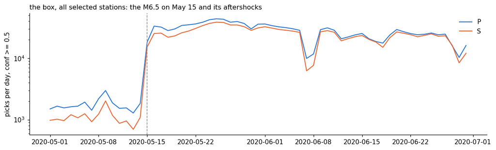

```python
daily = con.sql('''
    SELECT date_trunc('day', peak) AS day, pha, count(*) AS n
    FROM picks WHERE conf >= 0.5 GROUP BY day, pha ORDER BY day
''').df().pivot(index="day", columns="pha", values="n").fillna(0)

fig, ax = plt.subplots(figsize=(11, 3.4))
for ph, c in (("P", C_P), ("S", C_S)):
    ax.plot(daily.index, daily[ph], lw=1.4, color=c, label=ph)
ax.axvline(pd.Timestamp("2020-05-15"), color="#8a8a8a", lw=1, ls="--")
ax.set_yscale("log"); ax.set_ylabel("picks per day, conf >= 0.5"); ax.legend(frameon=False)
ax.set_title("the box, all selected stations: the M6.5 on May 15 and its aftershocks", loc="left", fontsize=10.5)
fig.tight_layout()
```

### The threshold is yours to choose

Everything at or above 0.2 is stored. How much a higher floor removes depends on the station and the sequence, so look before choosing.

```python
sweep = con.sql('''
    SELECT t.thr, count(*) FILTER (p.conf >= t.thr AND pha = 'P') AS P, count(*) FILTER (p.conf >= t.thr AND pha = 'S') AS S
    FROM picks p, (SELECT unnest([0.2, 0.3, 0.4, 0.5, 0.6, 0.7, 0.8, 0.9]) AS thr) t
    GROUP BY t.thr ORDER BY t.thr
''').df()
sweep["P_kept"] = (sweep.P / sweep.P.iloc[0]).round(3); sweep["S_kept"] = (sweep.S / sweep.S.iloc[0]).round(3)
sweep
```

|  | thr | P | S | P_kept | S_kept |
| --- | --- | --- | --- | --- | --- |
| 0 | 0.2 | 2184746 | 2111152 | 1.000 | 1.000 |
| 1 | 0.3 | 1812098 | 1731536 | 0.829 | 0.820 |
| 2 | 0.4 | 1561320 | 1439077 | 0.715 | 0.682 |
| 3 | 0.5 | 1341337 | 1180497 | 0.614 | 0.559 |
| 4 | 0.6 | 1186801 | 966724 | 0.543 | 0.458 |
| 5 | 0.7 | 1042478 | 743221 | 0.477 | 0.352 |
| 6 | 0.8 | 873141 | 477713 | 0.400 | 0.226 |
| 7 | 0.9 | 608600 | 169616 | 0.279 | 0.080 |

## 6. Coverage: which station-days were actually processed

A station-day with no rows may mean the archive held nothing, or that the campaign never read it, and the picks alone cannot tell the two apart. The public **manifests** help: each shard's manifest lists the station-days it processed with their pick counts (`records`: `tid`, `cha`, `yr`, `doy`, `npks`), so a station-day present there with `npks: 0` was read and yielded nothing above 0.2. Shards run on image d0ccf9b or later (from 2026-10-06, including the `western-reread2` re-read) also list **`outcomes`**, one per planned station-day, which says what happened even when nothing was read: `loaded`, `no_data` (archive listing had nothing), `no_channel`, `empty_read`, `not_found` (network-year absent), `denied`, `done`, or a not-read status (`timeout`, `throttled`, `too_big`, ...). Where an outcome exists it is the answer; for older shards only `records` is available.

Two things to know before trusting them. **Whether a station-day has picks is read from the Parquet, never from the manifest**: a shard that was preempted and resumed by another worker writes a manifest covering only the resuming attempt, while the first attempt's files stay in the bucket, so the manifest under-reports. And the shards found here are the ones named by the files we mirrored (`<shard_id>[-NNN].parquet`); a shard that processed our stations and wrote nothing into these partitions leaves no filename behind. Being exhaustive means fetching every manifest of the campaign (72,505 GETs for `western`, about twenty minutes); this cell does the cheap version.

```python
shard_ids = set()
for camp, net, year, month in PARTS:
    for p in (MIRROR / f"{camp}/picks/network={net}/year={year}/month={month:02d}").glob("*.parquet"):
        sid = p.stem
        if sid[-4] == "-" and sid[-3:].isdigit():           # strip the -001 sequence suffix
            sid = sid[:-4]
        shard_ids.add((camp, sid))
print(f"{len(shard_ids)} shards wrote into these partitions")

def fetch_manifest(key):
    camp, sid = key
    try:
        return camp, json.loads(fs.cat(f"{BUCKET}/{camp}/manifests/{sid}.json"))
    except FileNotFoundError:
        return camp, None

t0 = time.time()
with ThreadPoolExecutor(32) as ex:
    manifests = list(ex.map(fetch_manifest, sorted(shard_ids)))
print(f"fetched in {time.time() - t0:.0f} s; {sum(m is None for _, m in manifests)} missing")

rec = pd.DataFrame([dict(campaign=camp, **r) for camp, m in manifests if m for r in m["records"]])
# One outcome per planned station-day, from shards run on image d0ccf9b or later.
out = pd.DataFrame([dict(tid=o["tid"], yr=o["yr"], doy=o["doy"], outcome=o["status"])
                    for _, m in manifests if m for o in m.get("outcomes", [])],
                   columns=["tid", "yr", "doy", "outcome"])
if len(out):
    out["day"] = pd.to_datetime(out.yr.astype(str) + out.doy.astype(str).str.zfill(3), format="%Y%j").dt.date
    out = out.drop_duplicates(["tid", "day"], keep="last")[["tid", "day", "outcome"]]
else:
    out = pd.DataFrame(columns=["tid", "day", "outcome"])
print(f"{len(out):,} station-day outcomes (shards on image d0ccf9b or later)")
rec["day"] = pd.to_datetime(rec.yr.astype(str) + rec.doy.astype(str).str.zfill(3), format="%Y%j").dt.date
rec = rec[rec.tid.isin(sel.id) & (rec.day >= START) & (rec.day <= END)]
print(f"{len(rec):,} station-day records for our stations in the period, "
      f"{(rec.npks == 0).sum():,} of them with zero picks")
```

```
426 shards wrote into these partitions
```

```
fetched in 9 s; 0 missing
0 station-day outcomes (shards on image d0ccf9b or later)
4,046 station-day records for our stations in the period, 171 of them with zero picks
```

```python
# Expected station-days: each selected station on each day of the period it was operating.
days = pd.date_range(START, END, freq="D").date
expected = pd.DataFrame([(s.id, d) for s in sel.itertuples() for d in days
                         if s.start_date <= d <= s.end_date], columns=["tid", "day"])

# "picks" comes from the Parquet itself; the manifests add "read, no pick".
have_picks = con.sql("SELECT DISTINCT tid, CAST(date_trunc('day', peak) AS DATE) AS day FROM picks").df()
have_picks["day"] = pd.to_datetime(have_picks.day).dt.date
cov = (expected.merge(have_picks.assign(has_picks=True), on=["tid", "day"], how="left")
               .merge(rec[["tid", "day", "npks"]].drop_duplicates(["tid", "day"]), on=["tid", "day"], how="left")
               .merge(out, on=["tid", "day"], how="left"))
# Picks from the Parquet first; then what the reader recorded: an outcome of
# no_data / not_found / no_channel / empty_read means the archive had nothing
# pickable, which older manifests could not say.
NO_DATA = {"no_data", "not_found", "no_channel", "empty_read"}
cov["status"] = np.select(
    [cov.has_picks.eq(True), cov.npks.notna() | cov.outcome.eq("loaded"), cov.outcome.isin(NO_DATA)],
    ["picks", "read, no pick", "no data in archive"], "not processed")
summary = cov.status.value_counts()
print(f"{len(expected):,} expected station-days on {sel.id.nunique()} stations")
print((summary / len(cov)).round(3).to_string())

by_station = cov.groupby("tid").status.value_counts().unstack(fill_value=0)
never = by_station[by_station.get("picks", 0) + by_station.get("read, no pick", 0) == 0]
print(f"\n{len(never)} of {len(by_station)} stations have no processed day at all in the period")
print(never.head(10).to_string())
```

```
9,533 expected station-days on 166 stations
status
not processed    0.515
picks            0.467
read, no pick    0.018

71 of 166 stations have no processed day at all in the period
status      not processed  picks  read, no pick
tid
BK.HELL.               61      0              0
BK.HELL.00             61      0              0
BK.HELL.S0             61      0              0
BK.KCC.                61      0              0
CI.GRA.2C              61      0              0
CI.MLAC.2C             61      0              0
CI.TIN.2C              61      0              0
IM.NVAR.FB             61      0              0
LB.TPH.                61      0              0
NC.MCY.                61      0              0
```

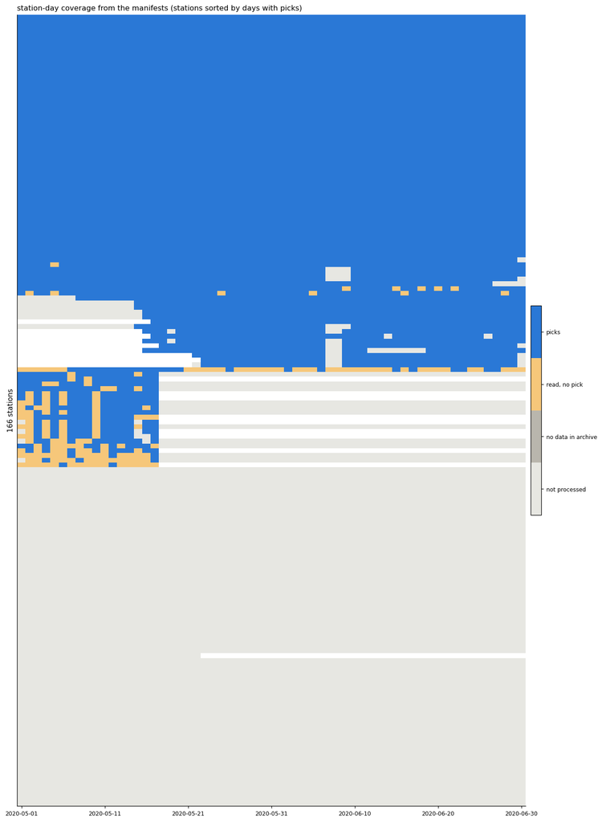

```python
order = by_station.sort_values("picks", ascending=False).index if "picks" in by_station else by_station.index
code_of = {"not processed": 0, "no data in archive": 1, "read, no pick": 2, "picks": 3}
grid = cov.pivot(index="tid", columns="day", values="status").reindex(order).apply(lambda c: c.map(code_of)).astype(float)

fig, ax = plt.subplots(figsize=(12, 0.09 * len(grid) + 1.4))
im = ax.imshow(grid.values, aspect="auto", cmap=plt.matplotlib.colors.ListedColormap(["#e7e7e2", "#b9b6ad", "#f6c77a", "#2a78d6"]),
               vmin=-0.5, vmax=3.5, interpolation="nearest")
ax.set_yticks([]); ax.set_ylabel(f"{len(grid)} stations")
xt = np.arange(0, len(days), 10); ax.set_xticks(xt); ax.set_xticklabels([str(days[i]) for i in xt], fontsize=8)
cb = fig.colorbar(im, ax=ax, ticks=[0, 1, 2, 3], fraction=0.02, pad=0.01)
cb.ax.set_yticklabels(["not processed", "no data in archive", "read, no pick", "picks"], fontsize=8)
ax.set_title("station-day coverage from the manifests (stations sorted by days with picks)", loc="left", fontsize=10.5)
fig.tight_layout()
```

```python
# Runs of consecutive unprocessed days on stations that otherwise have picks.
gaps = []
for tid, g in cov.sort_values("day").groupby("tid"):
    if (g.status == "picks").sum() < 10:
        continue
    run = []
    for row in g.itertuples():
        if row.status == "not processed":
            run.append(row.day)
        elif run:
            gaps.append((tid, run[0], run[-1], len(run))); run = []
    if run:
        gaps.append((tid, run[0], run[-1], len(run)))
gaps = pd.DataFrame(gaps, columns=["tid", "first_day", "last_day", "days"])
long_gaps = gaps[gaps.days >= 5].sort_values(["first_day", "tid"])
print(f"{len(long_gaps)} gaps of 5+ days on stations that have picks; by start day:")
print(long_gaps.groupby(["first_day", "last_day"]).agg(stations=("tid", "size"), days=("days", "first")).to_string())
```

```
15 gaps of 5+ days on stations that have picks; by start day:
                       stations  days
first_day  last_day
2020-05-01 2020-05-07         1     7
           2020-05-14         3    14
           2020-05-15         2    15
2020-05-18 2020-06-30         8    44
2020-06-12 2020-06-18         1     7
```

Gaps that start and end on the same days for many stations are shard boundaries (the queue is cut into 20-day shards of about 30 stations). A block of stations skipped for a whole shard is an archive outage, a shard the campaign has set aside (embargoed or awaiting review, listed on the [dashboard](https://seisscoped.org/QuakeScope/campaign_dashboard.html)), or a silent skip of the kind documented in western_pick_validation.html section 10. A gap of one to three days at the *start* of a shard window on stations that are otherwise complete is the signature of a shard resumed after a preemption, where the resuming worker's first write replaced the first attempt's first checkpoint file. Either is worth reporting (https://github.com/SeisSCOPED/QuakeScope/issues) with this table.

Read "not processed" with care. An audit in October 2026 found that most of it in `western` was a reader defect, not an empty archive: the band was chosen once per station for the whole campaign, so days when that band was absent (an `EH` year on a station later upgraded to `HH`) were never read. Those days are being re-read from 2026-10-08 (`western-reread2`), and the re-read records an outcome for each, so this category shrinks as it runs (32_outcomes_and_band_fallback.md). The rest is station-locations the planning table lists but the archive holds nothing for: the table carries every location code the metadata ever declared (`BK.HELL.`, `BK.HELL.00` and `BK.HELL.S0` are three rows for one instrument), and metadata outlives instruments. Some of it is the campaign's own silent skips, documented in western_pick_validation.html section 10. The manifests cannot separate the two; the archive can, by asking it for the day. Stations with picks on most days and a few missing ones are the rows worth asking about.

## 7. Export

Two shapes are useful downstream. A **per-station-day summary** for QC and coverage statements, and the **picks themselves** in the columns an associator expects. Both are written under `export/`.

```python
EXPORT = Path("export"); EXPORT.mkdir(exist_ok=True)

cov.to_csv(EXPORT / "coverage_station_days.csv", index=False)
per_station.to_csv(EXPORT / "picks_per_station.csv", index=False)

# The picks, filtered to the box and the period, one file, all columns. Parquet keeps the types.
con.sql(f"COPY (SELECT * EXCLUDE (latitude, longitude) FROM picks ORDER BY peak) TO '{EXPORT}/picks.parquet' (FORMAT PARQUET)")
n = con.sql(f"SELECT count(*) FROM '{EXPORT}/picks.parquet'").fetchone()[0]
print(f"picks.parquet: {n:,} rows, {(EXPORT / 'picks.parquet').stat().st_size / 1e6:.0f} MB")
```

```
picks.parquet: 4,295,898 rows, 132 MB
```

### For an associator

PyOcto takes a `DataFrame` with `station`, `time`, `phase` and `probability`; GaMMA takes `id`, `timestamp`, `type`, `prob` and `amp`. Both want the station table alongside. The mapping is the whole conversion; a confidence floor of 0.5 is a reasonable starting point for association and is not the catalogue's floor.

```python
picks_df = pd.read_parquet(EXPORT / "picks.parquet")
assoc = picks_df[picks_df.conf >= 0.5]

pyocto_picks = pd.DataFrame({"station": assoc.tid.str.rstrip("."),   # PyOcto keys stations as NET.STA[.LOC]
                             "time": assoc.peak, "phase": assoc.pha, "probability": assoc.conf})
pyocto_stations = sel.rename(columns={"id": "id", "latitude": "latitude", "longitude": "longitude", "elevation": "elevation"})
pyocto_stations = pyocto_stations.assign(id=pyocto_stations.id.str.rstrip("."))[["id", "latitude", "longitude", "elevation"]]

gamma_picks = pd.DataFrame({"id": assoc.tid, "timestamp": assoc.peak, "type": assoc.pha.str.lower(),
                            "prob": assoc.conf, "amp": assoc.amp})

pyocto_picks.to_parquet(EXPORT / "pyocto_picks.parquet"); pyocto_stations.to_csv(EXPORT / "pyocto_stations.csv", index=False)
gamma_picks.to_parquet(EXPORT / "gamma_picks.parquet")
print(f"{len(assoc):,} picks at conf >= 0.5 for association")
pyocto_picks.head()
```

```
2,521,834 picks at conf >= 0.5 for association
```

|  | station | time | phase | probability |
| --- | --- | --- | --- | --- |
| 4 | CI.TIN | 2020-05-01 00:00:46.408 | P | 0.708237 |
| 7 | NC.MEM | 2020-05-01 00:01:20.590 | S | 0.639534 |
| 14 | CI.GRA | 2020-05-01 00:05:00.018 | P | 0.809767 |
| 15 | CI.GRA | 2020-05-01 00:05:01.958 | S | 0.609104 |
| 18 | NN.LHV | 2020-05-01 00:06:19.318 | P | 0.834368 |

Running the associator is a separate step and a separate notebook: `seisbench_pyocto_ncedc.ipynb` shows PyOcto on picks of this shape.

## 8. Scaling up

The recipe above is the recipe at any size; only the byte counts change.

**A whole network-year.** Replace the month loop with the year:

```
aws s3 sync --no-sign-request s3://quakescope-picks-2026/western/picks/network=UW/year=2019/ quakescope_mirror/western/picks/network=UW/year=2019/
```

```
aws s3 sync --no-sign-request s3://quakescope-picks-2026/western/picks/ quakescope_mirror/western/picks/
aws s3 cp   --no-sign-request s3://quakescope-picks-2026/western/stations.parquet quakescope_mirror/western/
```

| network | objects | GB |  | network | objects | GB |
| --- | --- | --- | --- | --- | --- | --- |
| CI | 51,561 | 8.94 |  | UO | 10,136 | 1.31 |
| UW | 66,847 | 5.30 |  | AZ | 9,540 | 1.10 |
| PB | 14,441 | 5.27 |  | CC | 7,119 | 0.94 |
| NC | 101,863 | 3.41 |  | YN | 3,861 | 0.87 |
| BG | 5,495 | 2.01 |  | SB | 4,140 | 0.86 |
| BK | 21,426 | 1.77 |  | TA | 6,719 | 0.80 |
| NN | 12,120 | 1.47 |  | 75 others |  | 6.6 |

And by year: under 0.2 GB a year before 2003, 1.2 GB a year by 2008, 1.6 to 1.8 GB a year through the 2010s and 2.5 to 3.0 GB a year from 2019. The pre-2010 era is small because the archives hold fewer stations then, not because it was picked differently.

**Keeping a mirror current.** Embargoed years fill in as EarthScope opens them and compaction will rename objects; `aws s3 sync` re-run against the same local tree fetches only what changed. Record the date of any pull you publish from.

Reference for the layout, the rules and the known limits: [`docs/data_access.md`](https://github.com/SeisSCOPED/QuakeScope/blob/main/docs/data_access.md). Progress of every campaign: the [dashboard](https://seisscoped.org/QuakeScope/campaign_dashboard.html).